# COPS - multi-omic TCGA breast cancer patient stratification example

Teemu Rintala and Vittorio Fortino

2024-06-05

## Introduction

The molecular processes underlying genes, their expression and the resulting phenotypes manifest as different measurable features. Transcriptomics concerns the expression of gene-transcripts in the form of RNA, epigenomics concerns multiple aspects that affect transcription, such as DNA-methylation, genomics concerns the DNA sequence and in cancer especially its mutations, metabolomics concerns metabolites and so on. Each measurable aspect requires specialised equipment and protocols to obtain observations of each feature, but together they form a more complete characterisation of the molecular state of the sample compared to individual omics. Integrating data from multiple views is a problem that can be addressed with multi-view machine learning approaches and in fact, there already exist many multi-omic integration and analysis tools. For patient stratification the most relevant tools are joint dimensionality reduction methods and multi-view clustering methods.

In this vignette we will go over how `COPS` can be used to run multi- view clustering analysis within the same evaluation framework introduced in the multi-cohort clustering vignette based on a single view (i.e., RNA-Seq data). As an example we will use the TCGA breast cancer dataset which consists of approximately 700 patients.

## Multi-view clustering function

The `multi_omic_clustering`-function works as a fixed interface to several clustering methods and can be used to run several methods sequentially on the same dataset. On the other hand, `COPS` can be used to run CV folds and multiple methods in parallel. However, due to the computational requirements it may not be practical for some datasets. In such cases, it is possible to manually separate and distribute computations for each method and CV fold.

### Vignette required packages

This vignette makes use of data outside of `COPS` and therefore requires additional packages to be installed.

```r
if (!requireNamespace("TCGAbiolinks", quietly = TRUE)) {
  BiocManager::install("TCGAbiolinks")
}
```

[output not shown]

```
## Bioconductor version 3.19 (BiocManager 1.30.23), R 4.4.0 (2024-04-24)
```

```
## Installing package(s) 'TCGAbiolinks'
```

[output not shown]

```
## Old packages: 'BiocGenerics'
```

### Provided methods

| Method | R-package | Description | Reference |
| --- | --- | --- | --- |
| iClusterPlus | iClusterPlus | A Bayesian latent-variable model based clustering approach that generates cluster assignment based on joint inference across data types. Uses a modified Monte Carlo Newton-Raphson algorithm for optimi… | https://doi.org/10.1073/pnas.1208949110 |
| iClusterBayes | iClusterPlus | A Bayesian latent-variable model based clustering approach that generates cluster assignment based on joint inference across data types. Uses Bayesian inference and the Metropolis-Hastings algorithm t… | https://doi.org/10.1093/biostatistics/kxx017 |
| IntNMF | IntNMF | An integrative approach for disease subtype classification based on non-negative matrix factorization. | https://doi.org/10.1371/journal.pone.0176278 |
| MOFA2 | MOFA2 | Reconstructs a low-dimensional representation of the data using computationally efficient variational inference. Used for joint dimensionality reduction after which COPS applies single-view clustering… | https://doi.org/10.1186/s13059-020-02015-1 |
| ANF | ANF | Based on patient affinity networks that are calculated for each omic data type and fused into one network that is used for spectral clustering. | https://doi.org/10.1016/j.ymeth.2018.05.020 |
| kkmeans | COPS | Kernelized k-means implemented by COPS. Can use spectral approximation to initialize or use the global k-means algorithm to find global optimum. |  |
| kkmeanspp | COPS | Kernelized k-means++ implemented by COPS. Uses random initializations similar to k-means++. |  |
| mkkm_mr | COPS | Multiple Kernel K-Means with Matrix-induced Regularization calculates optimal weights for summing kernels such that redundancy is lowered while diversity of the selected kernels is increased. | https://doi.org/10.1609/aaai.v30i1.10249 |
| ECMC | COPS | Multi-view clustering with enhanced consensus is a multiple kernel method that aims to decompose the kernels corresponding to each view into a consensus and a disagreement kernel. The consensus kernel… | https://doi.org/10.1186/s12920-017-0306-x |

### Function signature

- `dat_list` : List of input data.frames for input.
- `meta_data` : A data.frame or a list that includes meta data for each view. Used to append CV details in the `COPS` pipeline. If it is not set, the metadata will still contain “id” which corresponds to the rownames of the first input.
- `multi_view_methods` : Vector of algorithm names to be applied. Available options are listed in the table above.
- `n_clusters` : Integer vector of the number of clusters to compute.
- `distance_metric` : Distance metric for clustering factorized data (only applicable to MOFA).
- `correlation_method` : Correlation method for distance_metric, if applicable.
- `standardize_data` : If set, each input feature is standardized to unit variance before clustering.
- `non_negativity_transform` : Vector of transformation method names for IntNMF to apply on each input. Options are: “logistic”, “rank” or “offset2”, non-matching inputs result in no transformation. NMF requires non-negative inputs, hence transorming the data may be necessary.
- `view_distributions` : A vector specifying the distribution to use for each view. Used by iCluster+, iClusterBayes and MOFA2. Options are “gaussian”, “bernoulli” and “poisson”.
- `icp_lambda` : iCluster+ L1 penalty for each view.
- `icp_burnin` : iCluster+ number of MCMC burn in samples for approximating joint distribution of latent variables.
- `icp_draw` : iCluster+ number of MCMC samples to draw after burn in for approximating joint distribution of latent variables.
- `icp_maxiter` : iCluster+ maximum number of Newton-Rhapson (EM) iterations.
- `icp_sdev` : iCluster+ MCMC random walk standard deviation.
- `icp_eps` : iCluster+ algorithm convergence threshold.
- `icb_burnin` : iClusteBayes number of samples for MCMC burn in.
- `icb_draw` : iClusteBayes number of MCMC samples to draw after burn in.
- `icb_sdev` : iClusteBayes MCMC random walk standard deviation.
- `icb_thin` : iClusteBayes MCMC thinning, only one sample in every icb_thin samples will be used.
- `nmf_maxiter` : Maximum number of iterations for IntNMF.
- `nmf_st.count` : Count stability for IntNMF.
- `nmf_n.ini` : Number of initializations for IntNMF.
- `nmf_ini.nndsvd` : By default, IntNMF uses NNDSVD for initialization. It can be disabled, but is strongly recommended.
- `nmf_scaling` : Determines how views are scaled for IntNMF. By default, the Frobenius norm ratio is used for scaling. A string other than the default will result in division by maximum value for each input.
- `mofa_convergence_mode` : MOFA convergence threshold. Options: “fast” (0.0005%), “medium” (0.00005%) or “slow” (0.000005%) deltaELBO change.
- `mofa_maxiter` : Maximum number of iterations for MOFA.
- `mofa_environment` : If set, uses the specified Python environment (with mofapy). Defaults to a `basilisk` environment managed by R.
- `mofa_lib_path` : Path to libpython. May be required if using non-default `mofa_environment`.
- `anf_neighbors` : Number of neighbours to use in knn-graph for ANF.
- `kernels` : Character vector of kernel names to use for each view. Options:
  - “linear” - Linear kernel based on standard dot product.
  - “gaussian”, “rbf” - Gaussian kernel, a.k.a. radial basis function.
  - “jaccard”, “tanimoto” - Kernel based on Jaccard index. Used for binary features.
  - “BWK” - Betweenness Weighted Kernel.
  - “PAMOGK” - PAthway Multi-Omics Graph Kernel.
  - “PIK” - Pathway Induced Kernel.
- `kernels_center` : Logical vector specifying which kernels should be centered.
- `kernels_normalize` : Logical vector specifying which kernels should be normalized.
- `kernels_scale_norm` : Logical vector specifying which kernels should be scaled to unit F-norm.
- `kernel_gammas` : Numeric vector specifying gamma for the Gaussian/RBF kernel: $e^{-\gamma\|\mathbf{x - x_i}\|_2}$.
- `pathway_networks` : List of `igraph` objects containing pathway networks. Required for pathway kernels.
- `pamogk_restart` : Restart probability for PAMOGK RWR.
- `kkmeans_maxiter` : Maximum number of iterations for kernel k-means.
- `kkmeans_n_init` : Number of initializations for kernel k-means.
- `mkkm_mr_lambda` : Regularization parameter for `mkkm_mr`. If it is a vector, `mkkm_mr` will be run for each element in the vector.
- `mkkm_mr_tolerance` : Convergence threshold for `mkkm_mr`.
- `mkkm_mr_initialization` : If `TRUE`, uses `mkkm_mr` result to initialize kernel k-means, otherwise runs kernel k-means++ on combined kernel.
- `mkkm_mr_mosek` : If `TRUE`, uses Rmosek for convex optimization instead of CVXR for `mkkm_mr`.
- `ecmc_a` : Regularization parameter alpha for `ECMC`. Higher values should “encourage” higher consensus.
- `ecmc_b` : Regularization parameter beta for `ECMC` Higher values should penalize disagreement more.
- `ecmc_eps` : Convergence threshold for `ECMC`
- `ecmc_maxiter` : Maximum number of iterations for `ECMC`
- `ecmc_mkkm_mr` : If `TRUE`, uses `mkkm_mr` on consensus kernels obtained from `ECMC`. Otherwise uses the average kernel and kernel k-means.
- `data_is_kernels` : If `TRUE`, input data is assumed to be kernel matrices. Otherwise kernels are computed based on input data and the given `kernels`.
- `zero_var_removal` : If `TRUE`, removes all zero variance features from the data.
- `mvc_threads` : Number of threads to use for supported operations.

### Pathway based multi-omic integration methods

`COPS` includes three kernel-based methods for pathway-based multi-omics integration. Technically, it is also possible to use the single-view pathway feature extraction methods and then apply a data-driven approach for multi-omic integration. The kernel-based options are 1) “BWK” which is briefly described below, 2) “PAMOGK” (https://doi.org/10.1093/bioinformatics/btaa655) uses z-scores to select dysregulated genes, random walk with restart (RWR) to expand the dysregulated gene set and shortest paths in each pathway networks to compute and summarize multiple pathway kernels for each omic, and 3) “PIK” (https://doi.org/10.1038/s41540-019-0086-3) uses pathway network adjacency matrices (specifically normalized Laplacians) to define edge-based pathway kernels.

These methods generate one kernel for each pathway and input omic which are then integrated by a multiple-kernel learning (MKL) approach. `COPS` has three possible implementations for combining kernels for clustering analysis. The simplest is the average kernel which is theoretically equivalent to concatenating the features. Then there is the Multiple Kernel K-Means with Matrix- induced Regularization (https://doi.org/10.1609/aaai.v30i1.10249) which learns optimal weights for summing the kernels and penalises redundancy between kernels. And finally, the multi-view enhanced consensus clustering which identifies and optimises consensus patterns between the input kernels before clustering. Note that to use thse methods, it is necessary to install either `Rmosek` or `CVXR`.

### Betweenness weighted kernel

This kernel is faster to compute than the PAMOGK, and similarly integrates pathway network information with gene-based data.

## Example

As mentioned in the introduction we will analyse the TCGA breast cancer dataset. `COPS` includes a subset of this dataset including gene-expression, DNA-methylation and Copy Number Variants. The DNA-methylation has been summarized for each gene so that the features can be mapped to genes for pathway-based methods.

For datasets of this size the methods can take a long time to finish, hence we will only demonstrate a direct application of the `multi_omic_clustering` function to run the analysis once on the full dataset. As is the case with other functions in the `COPS` pipeline, this function can be called within the complete evaluation framework including stability analysis with resampled data (via cross-fold validation).

```r
pipeline_start <- Sys.time()
set.seed(0)
mopw_clusters <- COPS::multi_omic_clustering(
  dat_list = COPS::brca_multi_omics,
  parallel = 1,
  multi_omic_methods = "mkkm_mr",
  kernels_center = TRUE,
  kernels_normalize = TRUE,
  mkkm_mr_mosek = FALSE,
  mkkm_mr_lambda = 1,
  kernels = rep("BWK", length(COPS::brca_multi_omics)),
  pathway_networks = COPS::pathway_networks,
  mvc_threads = 6,
  n_clusters = 2:8)
print(paste("Finished clustering in", COPS:::time_taken_string(pipeline_start)))
```

```
## [1] "Finished clustering in 12.90 mins"
```

### Internal evaluation

The internal metrics can be computed with respect to each view and `COPS` automatically evaluates the Silhouette for each view separately. However, we can also run it manually, although doing so may require some post-processing for readability.

```r
omics_d <- list()
omics_s <- list()
for (o in names(COPS::brca_multi_omics)) {
  omics_d[[o]] <- COPS::clustering_dissimilarity_from_data(
    t(COPS::brca_multi_omics[[o]]))
  omics_s[[o]] <- COPS::clustering_metrics(
    mopw_clusters, dissimilarity = omics_d[[o]])$metrics
  omics_s[[o]]$metric <- paste0(o, "_", omics_s[[o]]$metric)
  omics_s[[o]] <- reshape2::dcast(
    omics_s[[o]], k + m ~ metric, value.var = "value")
}
omics_s <- Reduce(plyr::join, omics_s)
omics_s
```

```
##   k       m mrna_Silhouette meth_gene_Silhouette cnv_Silhouette
## 1 2 mkkm_mr     0.043819440         -0.001362668     0.01490261
## 2 3 mkkm_mr     0.050607420         -0.003723404    -0.02360932
## 3 4 mkkm_mr     0.016280271         -0.013399001    -0.03222189
## 4 5 mkkm_mr     0.017706366         -0.020985015    -0.12830163
## 5 6 mkkm_mr     0.019223972         -0.022562227    -0.15780845
## 6 7 mkkm_mr     0.004209880         -0.030732334    -0.14237639
## 7 8 mkkm_mr    -0.003223242         -0.033007237    -0.07787159
```

For comparison, we can run the same method with standard linear kernels and let `COPS` perform internal evaluations:

```r
set.seed(0)
molk_res <- COPS::COPS(
  dat = COPS::brca_multi_omics,
  nruns = 2,
  nfolds = 5,
  parallel = 6,
  multi_omic_methods = "mkkm_mr",
  kernels_center = TRUE,
  kernels_normalize = TRUE,
  mkkm_mr_mosek = FALSE,
  mkkm_mr_lambda = 1,
  kernels = rep("linear", length(COPS::brca_multi_omics)),
  mvc_threads = 6,
  n_clusters = 2:8)
```

```
## [1] "Processing data sets ..."
## [1] "Starting multi-omic clustering and evaluation ..."
## [1] "Finished multi-omic clustering and evaluation in 3.52 hours"
## [1] "Starting clustering stability analysis ..."
## [1] "Finished clustering stability analysis in 5.77 mins"
```

```r
molk_scores <- COPS::scoring(molk_res, wsum = 1)
```

```r
molk_scores$all
```

```
##   k       m mkkm_mr_lambda cnv_Silhouette meth_gene_Silhouette mrna_Silhouette
## 1 2 mkkm_mr              1    0.043278653          0.076900413     0.071410467
## 2 3 mkkm_mr              1   -0.001913699          0.014411079     0.056614369
## 3 4 mkkm_mr              1   -0.015592555         -0.001037445     0.021145524
## 4 5 mkkm_mr              1   -0.064985232         -0.016915780     0.018484927
## 5 6 mkkm_mr              1   -0.087415085         -0.020068964     0.010414111
## 6 7 mkkm_mr              1   -0.092491424         -0.023970544     0.005847608
## 7 8 mkkm_mr              1   -0.109869733         -0.027595623     0.001435046
##   ClusteringStabilityJaccard ClusteringStabilityNMI ClusteringStabilityARI
## 1                  0.9272872              0.8672095              0.9228696
## 2                  0.9210426              0.8996965              0.9308694
## 3                  0.8906777              0.8998803              0.9205506
## 4                  0.7241546              0.7849618              0.7837056
## 5                  0.5467810              0.7193611              0.6347857
## 6                  0.4538310              0.6375813              0.5551381
## 7                  0.3919619              0.5757919              0.4935083
##   Clustering wsum
## 1    MKKM-MR    1
## 2    MKKM-MR    1
## 3    MKKM-MR    1
## 4    MKKM-MR    1
## 5    MKKM-MR    1
## 6    MKKM-MR    1
## 7    MKKM-MR    1
```

We can see that the silhouette scores in the original spaces are quite low for both linear kernels and the pathway kernels, albeit the former are slightly higher. In breast cancer the basal-like subtype tends to separate very well, so two clusters is expected to have the best cohesion and separation. The pathway- kernels also weight features differently from the euclidean distance used to calculate the silhouettes, so it is expected to yield worse results in this regard. But the pathway-kernels can highlight more relevant genes in terms of impact which can be evaluated in terms of survival differences between clusters, for example.

## Survival analysis

To download processed TCGA clinical data, we can use the TCGAbiolinks-package.

```r
clinical_data <- as.data.frame(TCGAbiolinks::TCGAquery_subtype("BRCA"))
```

```
## brca subtype information from:doi.org/10.1016/j.ccell.2018.03.014
```

The `subsample_survival_evaluation` expects a data.frame that contains the time and an event indicator. Depending on the clinical data format, it may be necessary to pre-process the survival data. In this case the times for event and event-free individuals are in different columns. We can use the `survival_preprocess` to reformat this data. The event also may have to be converted to TRUE/FALSE. TCGA also has some very long follow-up times, we can trim these by setting a cutoff.

```r
surv_data <- COPS::survival_preprocess(
  event_data = clinical_data,
  event_time_name = "days_to_death",
  follow_up_time_name = "days_to_last_followup",
  event_field_name = "vital_status",
  event_name = "Dead",
  event_time_cutoff = 3000)
```

After preprocessing survival data we can call `subsample_survival_evaluation` with the clustering result (`clusters`) and event information (`event_data`). The time and event columns can be named in the `survival_time_col` and `survival_event_col` arguments. The `event_data`-argument should also contain an id-column (named in the `row_id`-argument) that is used to match column names of the omics data to the event data. It may be necessary to translate the sample ids used in the omics data into patient ids. Note that missing survival data is automatically omitted in the evaluation. `subsample_survival_evaluation` fits two Cox proportional hazard models one with cluster indicators and one without and performs a likelihood-ratio test (LRT) to assess whether the difference between clusters is significant while allowing the Cox model to account for other critical variables such as age or cancer stage. Covariates must be included in `event_data` and can be named in the `survival_covariate_names`-argument. The function retuns a data.frame with the LRT p-value and Harrell’s concordance index for each result.

```r
mopw_clusters_surv <- mopw_clusters
mopw_clusters_surv[["id"]] <- gsub(
  "-[0-9]+[A-Z]+$", "", mopw_clusters_surv[["id"]])
mopw_surv_res <- COPS::subsample_survival_evaluation(
  event_data = surv_data,
  clusters = mopw_clusters_surv,
  survival_time_col = "time",
  survival_event_col = "event",
  survival_covariate_names = c(
    "age_at_initial_pathologic_diagnosis",
    "pathologic_stage"),
  row_id = "patient")
```

```r
mopw_surv_res
```

```
##        k       m cluster_significance concordance_index
##    <int>  <char>                <num>             <num>
## 1:     2 mkkm_mr           0.06332898         0.7722435
## 2:     3 mkkm_mr           0.08412147         0.7779094
## 3:     4 mkkm_mr           0.09081569         0.7891120
## 4:     5 mkkm_mr           0.05720155         0.7943255
## 5:     6 mkkm_mr           0.01165310         0.7942824
## 6:     7 mkkm_mr           0.07336807         0.7937438
## 7:     8 mkkm_mr           0.31324613         0.7912448
```

When used within the `COPS`-pipeline the returned object will be included in the returned list under the key “survival”. The `scoring`- function can then be used to generate summaries of cross-validated results similarly to other metrics discussed in the Psoriasis-vignette.

```r
molk_clusters_surv <- molk_res$clusters
molk_clusters_surv[["id"]] <- gsub(
  "-[0-9]+[A-Z]+$", "", molk_clusters_surv[["id"]])
molk_surv_res <- COPS::subsample_survival_evaluation(
  event_data = surv_data,
  clusters = molk_clusters_surv,
  survival_time_col = "time",
  survival_event_col = "event",
  survival_covariate_names = c(
    "age_at_initial_pathologic_diagnosis",
    "pathologic_stage"),
  row_id = "patient")
```

```r
molk_res$survival <- molk_surv_res
molk_scores <- COPS::scoring(molk_res, wsum = 1, significance_level = 0.05)
```

```r
molk_scores$all[,c("m", "k", "SurvivalLRtestRR", "SurvivalConcordance")]
```

```
##         m k SurvivalLRtestRR SurvivalConcordance
## 1 mkkm_mr 2              0.0           0.7660571
## 2 mkkm_mr 3              0.3           0.7829521
## 3 mkkm_mr 4              0.1           0.7841870
## 4 mkkm_mr 5              0.2           0.7842416
## 5 mkkm_mr 6              0.3           0.7914200
## 6 mkkm_mr 7              0.4           0.7946518
## 7 mkkm_mr 8              0.3           0.7991591
```

## Characterization

The next step after selecting the best result based on metrics is the visualisation and characterization of the groups. `COPS` provides a handful of tools to help select informative features and visualize them. For instance, `univariate_features` runs several test for differences between clusters for each feature.

```r
mopw_features <- list()
for (i in names(COPS::brca_multi_omics)) {
  mopw_features[[i]] <- COPS::univariate_features(
    COPS::brca_multi_omics[[i]],
    mopw_clusters[mopw_clusters[["k"]] == 3, "cluster"], # same order
    parallel = 6)
}
```

This gives us lists of various statistical test results and statistics. We can for example use the signal-to-noise-ratio to select interesting features:

```r
mopw_features_selected <- list()
for (i in names(COPS::brca_multi_omics)) {
  filter_i <- apply(abs(mopw_features[[i]][["snr"]]) > 0.75, 1, any)
  mopw_features_selected[[i]] <- names(which(filter_i))
}
```

Then, for visualizing we need to create a list of matrices containing only the relevant features.

```r
mopw_dat_selected <- list()
for (i in names(COPS::brca_multi_omics)) {
  if (length(mopw_features_selected[[i]]) > 0) {
    mopw_dat_selected[[i]] <- COPS::brca_multi_omics[[i]][mopw_features_selected[[i]],]
    rownames(mopw_dat_selected[[i]]) <- paste0(i, "_", rownames(mopw_dat_selected[[i]]))
  }
}
```

For annotating columns we can use the clinical information that we downloaded above. Annotations need to be a data.frame with rows matching the columns of the omics data.

```r
# We need to extract the patient IDs from the sample IDs again
p_id <- gsub("-[0-9]+[A-Z]+$", "", colnames(COPS::brca_multi_omics$mrna))
hm_annotations <- clinical_data[
  match(p_id, clinical_data[["patient"]]),
  c("age_at_initial_pathologic_diagnosis", "pathologic_stage", "BRCA_Subtype_PAM50")]
colnames(hm_annotations) <- c("age","stage", "PAM50")
hm_annotations[["cluster"]] <- mopw_clusters[mopw_clusters[["k"]] == 3, "cluster"]
```

The `heatmap_annotated` wraps `ComplexHeatmap::Heatmap` to conveniently visualize clustering results from one or more omics. The selected features could be given in the `feature_names` argument, but it can be easier to modify the input data manually (e.g., renaming the features). By default, the omics data are centered but not scaled to unit variance. The output is highly customisable, since all extra arguments are passed to `ComplexHeatmap::Heatmap`.

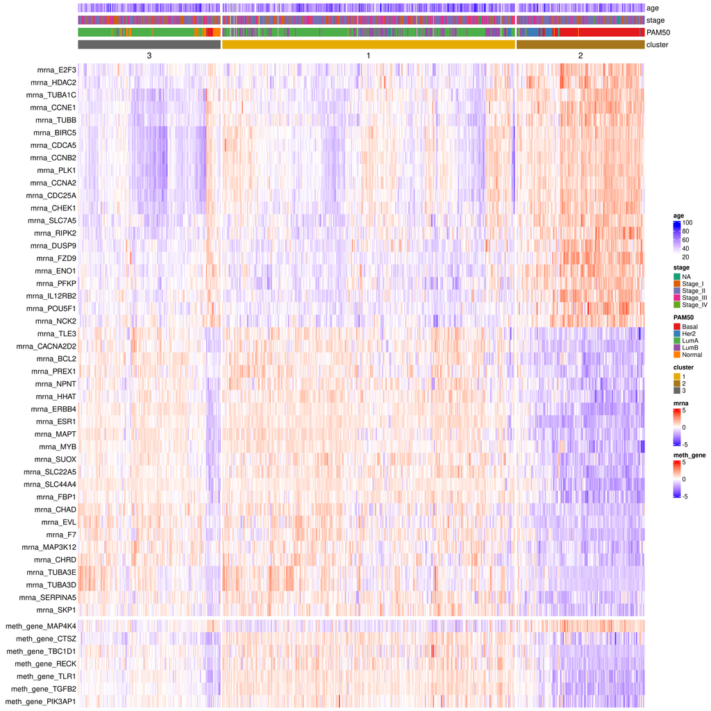

```r
COPS::heatmap_annotated(
  mopw_dat_selected,
  hm_annotations,
  scale = TRUE,
  column_split = hm_annotations[["cluster"]])
```